# Elena’s nascent RNAseq analysis

Jose Alejandro Romero Herrera

2022-02-11

# 1 Introduction

This is a clean version of Elena’s RNAseq analysis of the effect of Oct4 knockdown after pERK activation.

# 2 Load packages

```r
library(tidyverse)
library(DESeq2)
library(RColorBrewer) #colour scheme for hierarchical clustering heatmap
library(ggdendro)
library(ggrepel)
library(reshape2)
library(apeglm) #for LFC shrinkage in DESEq2
library(genefilter) #top var genes
library(pheatmap)
library(readxl)
library(xlsx)
library(biomaRt)
```

Create results folder for this notebook

```r
results_folder <- "../results/complete_deseq2_analysis/"

if(!file.exists(results_folder)){
  dir.create(results_folder)
}
```

# 3 Load data

```r
data_path <- "../data/counts_gene-id_gene.txt"
data <- read.delim(data_path, as.is=T)
head(data)
```

|  | Geneid | Chr | Start | End | Strand | Length | X8h_DOX_a_S4_uniq | X8h_DOX_b_S5_uniq | X8h_DOX_d_S6_uniq | X8h_H2O_a_S1_uniq | X8h_H2O_b_S2_uniq | X8h_H2O_d_S3_uniq | DOX_2h_ETOH_a_S10_uniq | DOX_2h_ETOH_b_S11_uniq | DOX_2h_ETOH_d_S12_uniq | H2O_2h_4OHT_a_S13_uniq | H2O_2h_4OHT_b_S14_uniq | H2O_2h_4OHT_d_S15_uniq | H2O_2h_ETOH_a_S7_uniq | H2O_2h_ETOH_b_S8_uniq | H2O_2h_ETOH_d_S9_uniq | DOX_2h_4OHT_a_S16_uniq | DOX_2h_4OHT_b_S17_uniq | DOX_2h_4OHT_d_S18_uniq | DOX_8h_4OHT_a_S28_uniq | DOX_8h_4OHT_b_S29_uniq | DOX_8h_4OHT_d_S30_uniq | DOX_8h_ETOH_a_S22_uniq | DOX_8h_ETOH_b_S23_uniq | … |
| --- | --- | --- | --- | --- | --- | --- | --- | --- | --- | --- | --- | --- | --- | --- | --- | --- | --- | --- | --- | --- | --- | --- | --- | --- | --- | --- | --- | --- | --- | --- |
| 1 | ENSMUSG00000102693 | 1 | 3073253 | 3074322 | + | 1070 | 0 | 2 | 0 | 0 | 0 | 1 | 0 | 0 | 0 | 0 | 0 | 0 | 0 | 0 | 0 | 0 | 0 | 0 | 0 | 0 | 0 | 0 | 0 | … |
| 2 | ENSMUSG00000051951 | 1 | 3205901 | 3671498 | - | 465598 | 58 | 67 | 48 | 14 | 27 | 29 | 113 | 58 | 49 | 96 | 49 | 67 | 63 | 54 | 24 | 120 | 70 | 89 | 93 | 129 | 134 | 171 | 132 | … |
| 3 | ENSMUSG00000103377 | 1 | 3365731 | 3368549 | - | 2819 | 0 | 0 | 0 | 0 | 0 | 0 | 0 | 0 | 0 | 0 | 0 | 0 | 0 | 0 | 0 | 0 | 0 | 0 | 0 | 0 | 0 | 0 | 0 | … |
| 4 | ENSMUSG00000104017 | 1 | 3375556 | 3377788 | - | 2233 | 0 | 0 | 0 | 0 | 0 | 0 | 0 | 0 | 0 | 0 | 0 | 0 | 0 | 0 | 0 | 0 | 0 | 0 | 0 | 0 | 0 | 0 | 0 | … |
| 5 | ENSMUSG00000103025 | 1 | 3464977 | 3467285 | - | 2309 | 0 | 0 | 0 | 0 | 0 | 0 | 0 | 0 | 0 | 0 | 0 | 0 | 0 | 0 | 0 | 0 | 0 | 0 | 0 | 0 | 0 | 0 | 0 | … |
| 6 | ENSMUSG00000103201 | 1 | 3512451 | 3514507 | - | 2057 | 0 | 0 | 0 | 0 | 0 | 0 | 0 | 0 | 0 | 0 | 0 | 0 | 0 | 0 | 0 | 0 | 0 | 0 | 0 | 0 | 0 | 0 | 0 | … |

Separate counts from gene metadata

```r
gene_metadata <- data[,1:6]
rownames(data) <- data$Geneid
data <- data[,-c(1:6)]
```

## 3.1 Prepare gene names and ids

Getting gene names from the mouse ensembl data base using Biomart

```r
genes_biomart <- data.frame(ensembl_gene_id = as.character(gene_metadata$Geneid))
```

```r
getGeneAnnotationsMM = function(d="./",force=F){

  mart <- useMart(
    host="https://www.ensembl.org", biomart = 'ENSEMBL_MART_ENSEMBL',
    dataset = 'mmusculus_gene_ensembl')

  annot <- biomaRt::getBM(
    attributes = c(
      "ensembl_gene_id",
      "external_gene_name",
      "description"),
    mart = mart)

  return(annot)
}

gene_annot <- getGeneAnnotationsMM()
genes_biomart <- merge(genes_biomart, gene_annot, by.x = "ensembl_gene_id", sort = F, all.x = T)
head(genes_biomart)
```

|  | ensembl_gene_id | external_gene_name | description |
| --- | --- | --- | --- |
| 1 | ENSMUSG00000102693 | 4933401J01Rik | RIKEN cDNA 4933401J01 gene [Source:MGI Symbol;Acc:MGI:1918292] |
| 2 | ENSMUSG00000051951 | Xkr4 | X-linked Kx blood group related 4 [Source:MGI Symbol;Acc:MGI:3528744] |
| 3 | ENSMUSG00000103377 | Gm37180 | predicted gene, 37180 [Source:MGI Symbol;Acc:MGI:5610408] |
| 4 | ENSMUSG00000104017 | Gm37363 | predicted gene, 37363 [Source:MGI Symbol;Acc:MGI:5610591] |
| 5 | ENSMUSG00000103025 | Gm37686 | predicted gene, 37686 [Source:MGI Symbol;Acc:MGI:5610914] |
| 6 | ENSMUSG00000103201 | Gm37329 | predicted gene, 37329 [Source:MGI Symbol;Acc:MGI:5610557] |

Replacing missing gene names for original ensembl id

```r
genes_biomart$external_gene_name[is.na(genes_biomart$external_gene_name)] <- genes_biomart$ensembl_gene_id[is.na(genes_biomart$external_gene_name)]
```

Checking duplicates

```r
# Check for gene id and name duplicates
check_duplicates <- function(x, unique = T, show = F) {
  duplicates <- sum(duplicated(x))

  if (duplicates == 0) {
    print("There are no duplicates")
    invisible(x)
  }
  else{
    print(paste0("There are ",duplicates," duplicated IDs"))
    if (show) {
      print(table(x[duplicated(x)]))
    }
    if (unique) {
      print(paste0("Making them unique"))
      invisible(make.names(x, unique = T))
    }
    else{
      invisible(x)
    }
  }
}

check_duplicates(genes_biomart$ensembl_gene_id, unique = F)
```

```
## [1] "There are no duplicates"
```

```r
check_duplicates(genes_biomart$external_gene_name, unique = F, show = T)
```

```
## [1] "There are 80 duplicated IDs"
##
##                 Aldoa      Atp5o      Ddit3      Dpep2       Gcat    Gm28040
##         62          1          1          1          1          1          1
##     Gm4430      Ndor1        Nnt    Olfr290      Pakap     Ptp4a1    Septin2
##          1          2          1          1          2          1          1
## St6galnac2   Vmn1r216    Zc3h11a
##          1          1          1
```

## 3.2 Prepare sample metadata

Extract information (metadata) from sample column names

```r
names = colnames(data)
names = sapply(names,function(x) gsub("X8h","X_8h",x))
p1 = "(.*)_(.*)_(.*)_(.*)_(.*)_uniq"
colData <- data.frame(str_match(names,p1),stringsAsFactors = F)
colnames(colData) = c("Sample","Dox","Time","Tam","Rep","Rep2")
colData$SampleName = colnames(data)
colData$TimePt = as.numeric(str_match(colData$Time,"^(.*)h")[,2])

# samples to fix: the Tam field should be empty
# and the values there should move to Dox
## Jose: This does not seem to apply to the 8h time point, i believe it is for the ones before the 2nd treatment
idx = colData$Dox=="X"
colData[idx,"Dox"] = colData[idx,"Tam"]
colData[idx,"Tam"] = NA

colData$SampleNameShort = with(colData,paste(Dox,Tam,Time,Rep2, sep="_"))
colData$ShortLabel = with(colData,paste(Dox,Tam,Time, sep="_"))
colData$ShortLabelTime = with(colData,paste(Dox,Tam, sep="_"))
colData$ShortLabel = factor(colData$ShortLabel)
colData$ShortLabel = relevel(colData$ShortLabel, "H2O_NA_8h")
```

```r
head(colData)
```

|  | Sample | Dox | Time | Tam | Rep | Rep2 | SampleName | TimePt | SampleNameShort | ShortLabel | ShortLabelTime |
| --- | --- | --- | --- | --- | --- | --- | --- | --- | --- | --- | --- |
| 1 | X_8h_DOX_a_S4_uniq | DOX | 8h | NA | a | S4 | X8h_DOX_a_S4_uniq | 8 | DOX_NA_8h_S4 | DOX_NA_8h | DOX_NA |
| 2 | X_8h_DOX_b_S5_uniq | DOX | 8h | NA | b | S5 | X8h_DOX_b_S5_uniq | 8 | DOX_NA_8h_S5 | DOX_NA_8h | DOX_NA |
| 3 | X_8h_DOX_d_S6_uniq | DOX | 8h | NA | d | S6 | X8h_DOX_d_S6_uniq | 8 | DOX_NA_8h_S6 | DOX_NA_8h | DOX_NA |
| 4 | X_8h_H2O_a_S1_uniq | H2O | 8h | NA | a | S1 | X8h_H2O_a_S1_uniq | 8 | H2O_NA_8h_S1 | H2O_NA_8h | H2O_NA |
| 5 | X_8h_H2O_b_S2_uniq | H2O | 8h | NA | b | S2 | X8h_H2O_b_S2_uniq | 8 | H2O_NA_8h_S2 | H2O_NA_8h | H2O_NA |
| 6 | X_8h_H2O_d_S3_uniq | H2O | 8h | NA | d | S3 | X8h_H2O_d_S3_uniq | 8 | H2O_NA_8h_S3 | H2O_NA_8h | H2O_NA |

# 4 DESEQ pre-analysis

Removing rows with no counts

```r
filter <- rowSums(data) > 1
print(paste0("Removing ", nrow(data) - sum(filter), " rows"))
```

```
## [1] "Removing 4897 rows"
```

```r
data <- data[filter,]
```

## 4.1 Create DESEQ object

```r
#full condition
dds <- DESeqDataSetFromMatrix(data, colData, design = ~ ShortLabel)
dds <- DESeq(dds)
```

## 4.2 Vst normalization

```r
vsd <- vst(dds)
```

### 4.2.1 Principal component plot of the samples

PCA plot using the first two components

```r
pcaData <- plotPCA(vsd, intgroup=c("ShortLabel"), returnData=TRUE)
percentVar <- round(100 * attr(pcaData, "percentVar"))
```

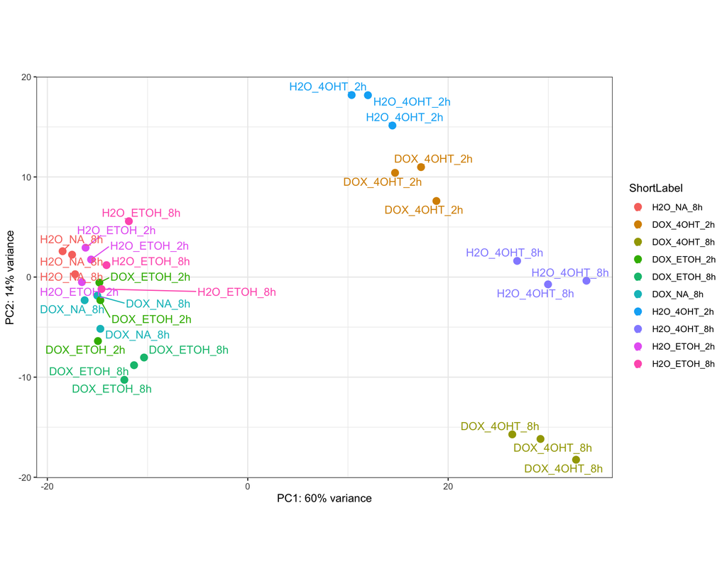

```r
ggplot(pcaData, aes(PC1, PC2, color=ShortLabel, label=ShortLabel)) +
  geom_point(size=3) + geom_text_repel() +
  xlab(paste0("PC1: ",percentVar[1],"% variance")) +
  ylab(paste0("PC2: ",percentVar[2],"% variance")) +
  coord_fixed() + theme_bw()
```

### 4.2.2 Heatmap of the sample-to-sample distances

This plot shows how far away are each sample from each other. The darker the blue, the closer they are.

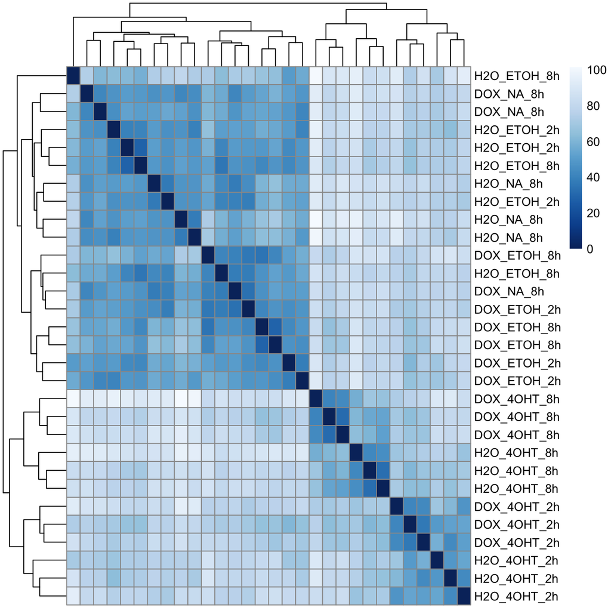

```r
sampleDists <- dist(t(assay(vsd)))
sampleDistMatrix <- as.matrix(sampleDists)
rownames(sampleDistMatrix) <- vsd$ShortLabel
colnames(sampleDistMatrix) <- NULL
colors <- colorRampPalette( rev(brewer.pal(9, "Blues")) )(255)
pheatmap(sampleDistMatrix,
         clustering_distance_rows=sampleDists,
         clustering_distance_cols=sampleDists,
         col=colors)
```

# 5 DE analysis

We have to do several DE analysis and create a list with all DE across conditions and timepoints

```r
LFC <- 1
alpha <- 0.05

filter_results <- function(result,LFC, alpha){
    result <- as.data.frame(result)
    result <- result[complete.cases(result),]
    result <- result[abs(result$log2FoldChange) > LFC & result$padj < alpha,]
    return(result)
}

result_list <- list()
```

## 5.1 0h comparisons

DOX_NA_8h vs H2O_NA_8h The proper reference level is already establish

```r
resultsNames(dds)
```

```
##  [1] "Intercept"                           "ShortLabel_DOX_4OHT_2h_vs_H2O_NA_8h"
##  [3] "ShortLabel_DOX_4OHT_8h_vs_H2O_NA_8h" "ShortLabel_DOX_ETOH_2h_vs_H2O_NA_8h"
##  [5] "ShortLabel_DOX_ETOH_8h_vs_H2O_NA_8h" "ShortLabel_DOX_NA_8h_vs_H2O_NA_8h"
##  [7] "ShortLabel_H2O_4OHT_2h_vs_H2O_NA_8h" "ShortLabel_H2O_4OHT_8h_vs_H2O_NA_8h"
##  [9] "ShortLabel_H2O_ETOH_2h_vs_H2O_NA_8h" "ShortLabel_H2O_ETOH_8h_vs_H2O_NA_8h"
```

```r
res <- results(dds, name = "ShortLabel_DOX_NA_8h_vs_H2O_NA_8h")
result_list[["DOX_NA_8h_vs_H2O_NA_8h"]] <- filter_results(res, LFC, alpha)
```

## 5.2 2h comparisons

DOX_ETOH_2h vs H2O_ETOH_2h H2O_4OHT_2h vs H2O_ETOH_2h DOX_4OHT_2h vs H2O_ETOH_2h

```r
dds$ShortLabel <- relevel(dds$ShortLabel, ref = "H2O_ETOH_2h")
dds <- DESeq(dds)
resultsNames(dds)
```

```
##  [1] "Intercept"
##  [2] "ShortLabel_H2O_NA_8h_vs_H2O_ETOH_2h"
##  [3] "ShortLabel_DOX_4OHT_2h_vs_H2O_ETOH_2h"
##  [4] "ShortLabel_DOX_4OHT_8h_vs_H2O_ETOH_2h"
##  [5] "ShortLabel_DOX_ETOH_2h_vs_H2O_ETOH_2h"
##  [6] "ShortLabel_DOX_ETOH_8h_vs_H2O_ETOH_2h"
##  [7] "ShortLabel_DOX_NA_8h_vs_H2O_ETOH_2h"
##  [8] "ShortLabel_H2O_4OHT_2h_vs_H2O_ETOH_2h"
##  [9] "ShortLabel_H2O_4OHT_8h_vs_H2O_ETOH_2h"
## [10] "ShortLabel_H2O_ETOH_8h_vs_H2O_ETOH_2h"
```

```r
res <- results(dds, name = "ShortLabel_DOX_ETOH_2h_vs_H2O_ETOH_2h")
result_list[["DOX_ETOH_2h_vs_H2O_ETOH_2h"]] <- filter_results(res, LFC, alpha)

res <- results(dds, name = "ShortLabel_H2O_4OHT_2h_vs_H2O_ETOH_2h")
result_list[["H2O_4OHT_2h_vs_H2O_ETOH_2h"]] <- filter_results(res, LFC, alpha)

res <- results(dds, name = "ShortLabel_DOX_4OHT_2h_vs_H2O_ETOH_2h")
result_list[["DOX_4OHT_2h_vs_H2O_ETOH_2h"]] <- filter_results(res, LFC, alpha)
```

## 5.3 8h comparisons

DOX_ETOH_8h vs H2O_ETOH_8h H2O_4OHT_8h vs H2O_ETOH_8h DOX_4OHT_8h vs H2O_ETOH_8h

```r
dds$ShortLabel <- relevel(dds$ShortLabel, ref = "H2O_ETOH_8h")
dds <- DESeq(dds)
resultsNames(dds)
```

```
##  [1] "Intercept"
##  [2] "ShortLabel_H2O_ETOH_2h_vs_H2O_ETOH_8h"
##  [3] "ShortLabel_H2O_NA_8h_vs_H2O_ETOH_8h"
##  [4] "ShortLabel_DOX_4OHT_2h_vs_H2O_ETOH_8h"
##  [5] "ShortLabel_DOX_4OHT_8h_vs_H2O_ETOH_8h"
##  [6] "ShortLabel_DOX_ETOH_2h_vs_H2O_ETOH_8h"
##  [7] "ShortLabel_DOX_ETOH_8h_vs_H2O_ETOH_8h"
##  [8] "ShortLabel_DOX_NA_8h_vs_H2O_ETOH_8h"
##  [9] "ShortLabel_H2O_4OHT_2h_vs_H2O_ETOH_8h"
## [10] "ShortLabel_H2O_4OHT_8h_vs_H2O_ETOH_8h"
```

```r
res <- results(dds, name = "ShortLabel_DOX_ETOH_8h_vs_H2O_ETOH_8h")
result_list[["DOX_ETOH_8h_vs_H2O_ETOH_8h"]] <- filter_results(res, LFC, alpha)

res <- results(dds, name = "ShortLabel_H2O_4OHT_8h_vs_H2O_ETOH_8h")
result_list[["H2O_4OHT_8h_vs_H2O_ETOH_8h"]] <- filter_results(res, LFC, alpha)

res <- results(dds, name = "ShortLabel_DOX_4OHT_8h_vs_H2O_ETOH_8h")
result_list[["DOX_4OHT_8h_vs_H2O_ETOH_8h"]] <- filter_results(res, LFC, alpha)
```

## 5.4 All DE genes for all conditions

```r
DE_ids <- unique(unlist(lapply(result_list, rownames), use.names = F))
```

# 6 Save all results

In an excel file

```r
add_data <- function(name,data,workbook){
  df <- data[name]
  new_sheet <- createSheet(workbook, sheetName = name)
  addDataFrame(df, sheet = new_sheet)
}
```

```r
wb <- createWorkbook()
sheet_names <- names(result_list)

lapply(sheet_names, FUN = add_data, result_list, wb)
```

[output not shown]

```r
saveWorkbook(wb, file = paste0(results_folder, "DEG_all_comparisons.xlsx"))
```

# 7 Heatmaps

```r
vsd <- assay(vsd)

vsd <- aggregate(t(vsd), by = list(colData$ShortLabel), mean)
vsd_names <- vsd[,1]
vsd <- vsd[,-1]
vsd <- data.frame(t(vsd))
colnames(vsd) <- vsd_names
```

## 7.1 pERK activation only

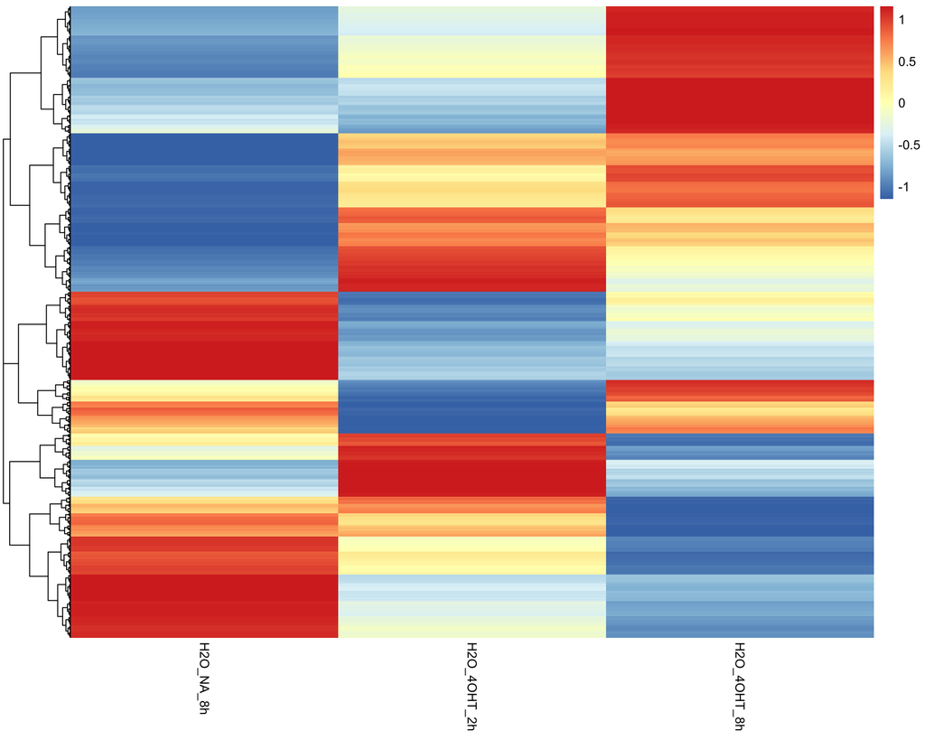

```r
perk_activation <- vsd[DE_ids,c("H2O_NA_8h", "H2O_4OHT_2h", "H2O_4OHT_8h")]

pheatmap(perk_activation, show_rownames = F, cluster_cols = F, scale = "row")
```

## 7.2 pERK activation and OCT4 KO

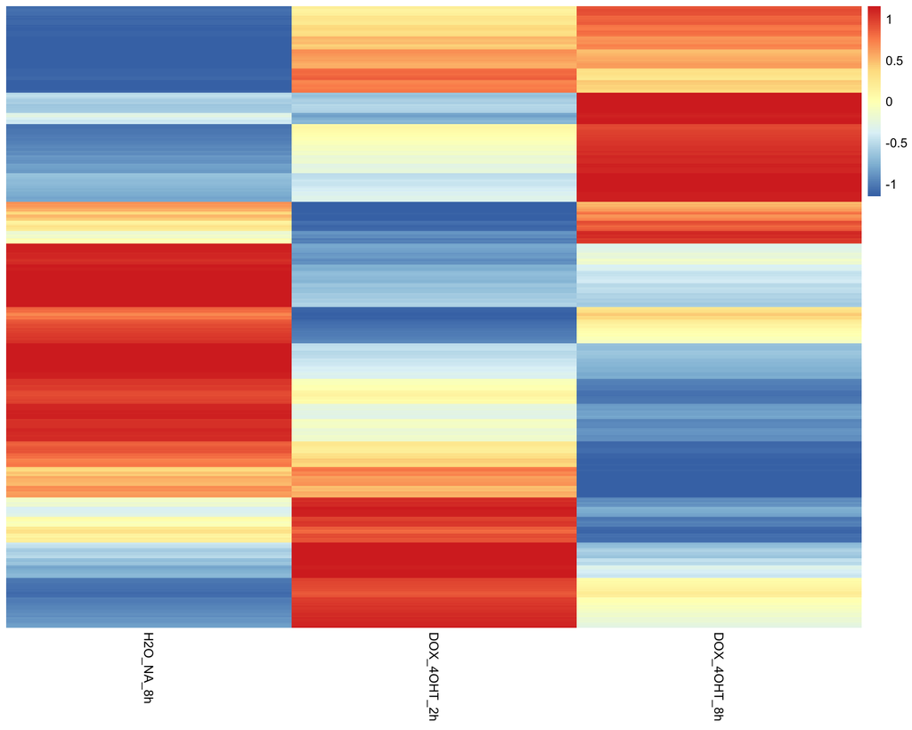

```r
oct4_downregulation <- vsd[DE_ids,c("H2O_NA_8h", "DOX_4OHT_2h", "DOX_4OHT_8h")]

pheatmap(oct4_downregulation, show_rownames = F, cluster_cols = F, treeheight_row = 0, scale = "row")
```

## 7.3 All

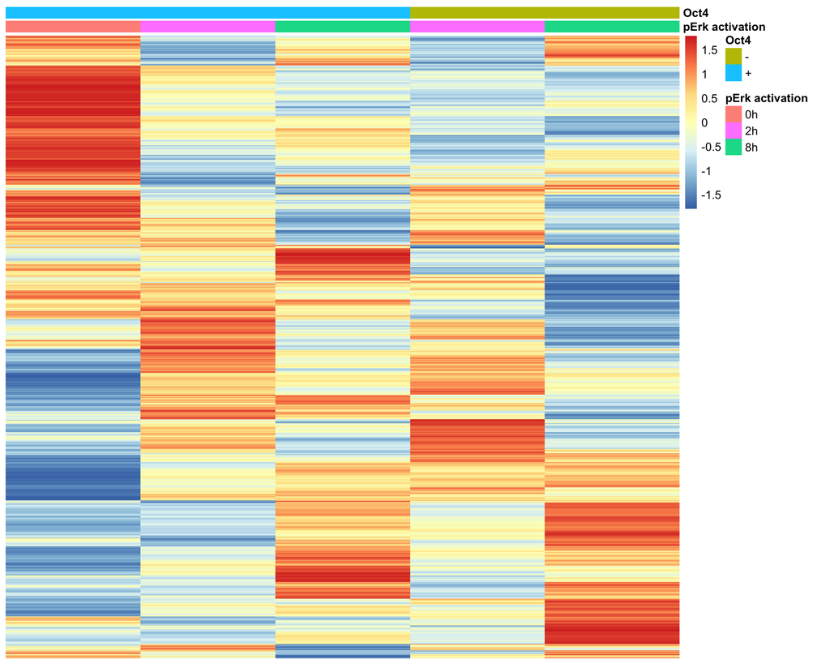

```r
heatmap_data <- vsd[DE_ids, c("H2O_NA_8h", "H2O_4OHT_2h", "H2O_4OHT_8h", "DOX_4OHT_2h", "DOX_4OHT_8h")]

annot_col <- data.frame(pErk = c("0h", "2h","8h","2h","8h"),
                        Oct4 = c("+", "+", "+","-","-"),
                        row.names = colnames(heatmap_data))

colnames(annot_col)[1] <- "pErk activation"

pheatmap(heatmap_data, show_rownames = F, cluster_cols = F, treeheight_row = 0, scale = "row", show_colnames = F, annotation_col = annot_col)
```

# 8 Josh’s requests

These plots were asked by Josh for a grant report

## 8.1 Only UP regulated Genes in the pERK time course

```r
pERK_results <- result_list[c(3,6,4,7)]

test <- function(x){
 return(rownames(x[x$log2FoldChange > 0,]))
}

DE_ids_up <- unique(unlist(lapply(pERK_results,test), use.names = F))
```

```r
heatmap_data <- vsd[DE_ids_up, c("H2O_NA_8h", "H2O_4OHT_2h", "H2O_4OHT_8h", "DOX_4OHT_2h", "DOX_4OHT_8h")]

annot_col <- data.frame(pErk = c("0h", "2h","8h","2h","8h"),
                        Oct4 = c("+", "+", "+","-","-"),
                        row.names = colnames(heatmap_data))

colnames(annot_col)[1] <- "pErk activation"
```

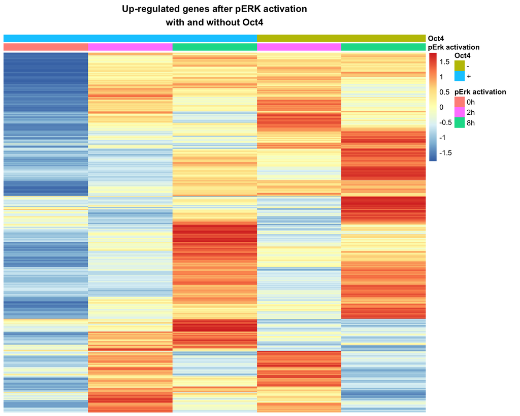

```r
pheatmap(heatmap_data, show_rownames = F, cluster_cols = F, treeheight_row = 0, scale = "row", show_colnames = F,
         annotation_col = annot_col, cluster_rows = T,
         main = "Up-regulated genes after pERK activation\nwith and without Oct4")
```

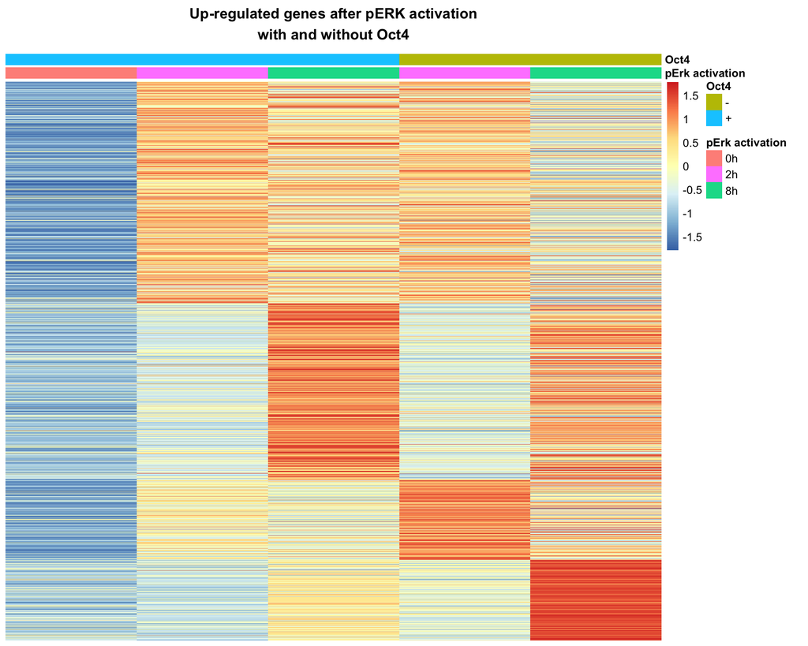

```r
pheatmap(heatmap_data, show_rownames = F, cluster_cols = F, treeheight_row = 0, scale = "row", show_colnames = F,
         annotation_col = annot_col, cluster_rows = F,
         main = "Up-regulated genes after pERK activation\nwith and without Oct4")
```

Divide clusters and select 2h and 8h cluster

```r
cluster_2h <- t(scale(t(heatmap_data[,c("H2O_NA_8h","H2O_4OHT_2h", "DOX_4OHT_2h")])))
cluster_2h <- hclust(dist(cluster_2h))

cluster_8h <- t(scale(t(heatmap_data[,c("H2O_NA_8h","H2O_4OHT_8h", "DOX_4OHT_8h")])))
cluster_8h <- hclust(dist(cluster_8h))
```

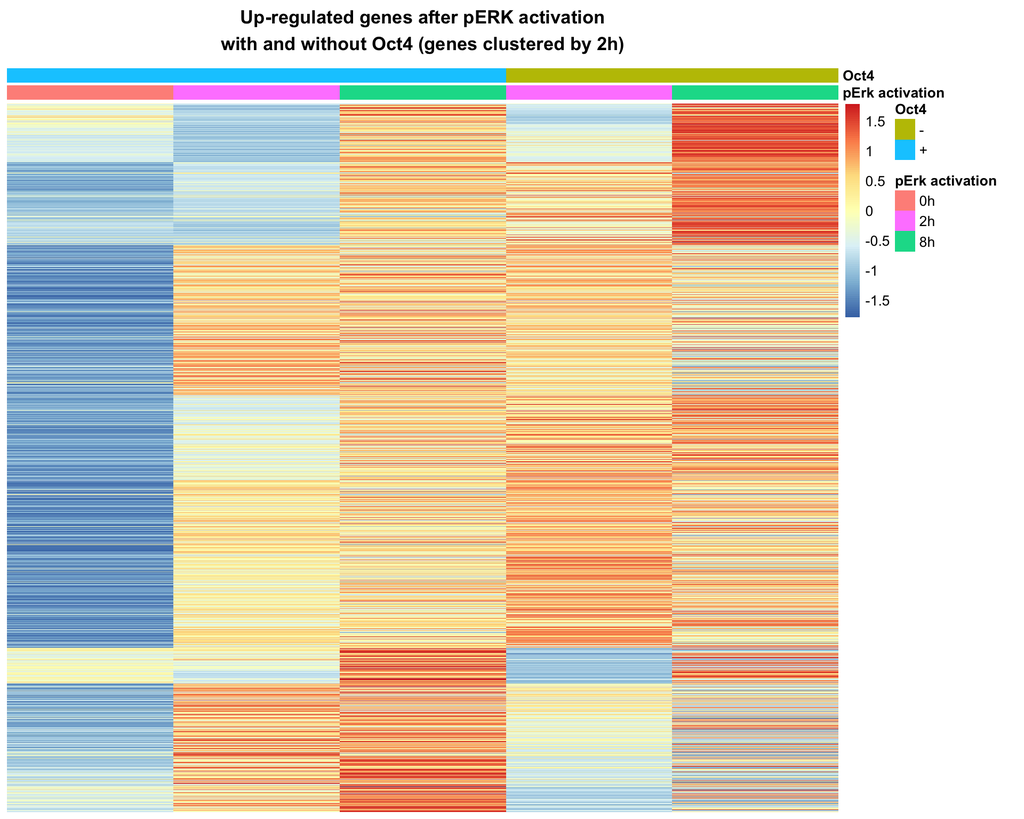

```r
pheatmap(heatmap_data, show_rownames = F, cluster_cols = F, cluster_rows = cluster_2h,
         treeheight_row = 0, scale = "row", show_colnames = F, annotation_col = annot_col,
         main = "Up-regulated genes after pERK activation\nwith and without Oct4 (genes clustered by 2h)")
```

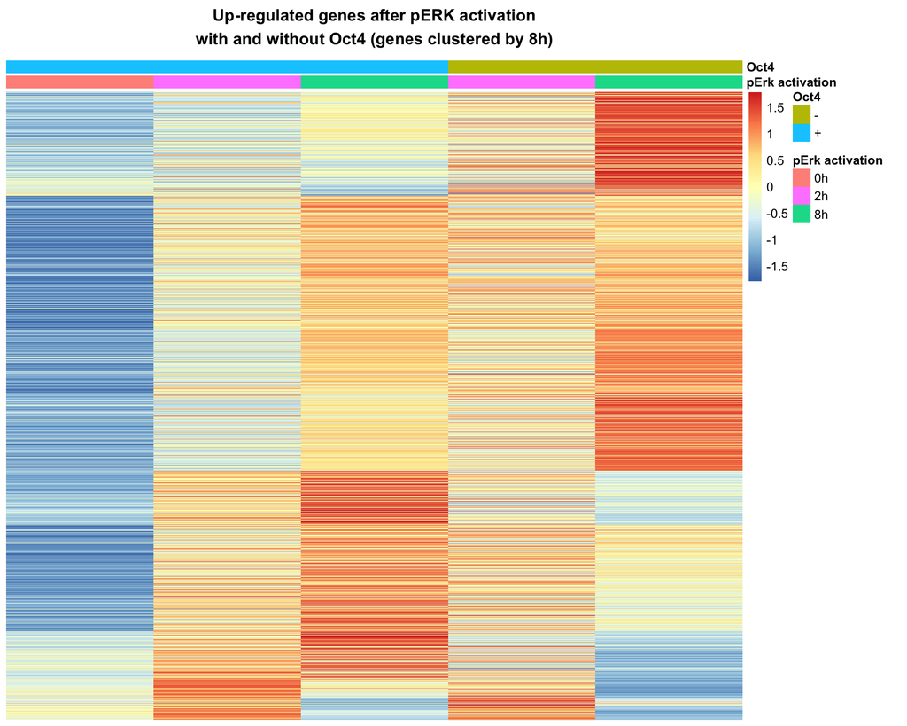

```r
pheatmap(heatmap_data, show_rownames = F, cluster_cols = F,cluster_rows = cluster_8h,
         treeheight_row = 0, scale = "row", show_colnames = F, annotation_col = annot_col,
         main = "Up-regulated genes after pERK activation\nwith and without Oct4 (genes clustered by 8h)")
```

## 8.2 Only DOWN regulated Genes in the pERK time course

```r
pERK_results <- result_list[c(3,6,4,7)]

test <- function(x){
 return(rownames(x[x$log2FoldChange < 0,]))
}

DE_ids_down <- unique(unlist(lapply(pERK_results,test), use.names = F))
```

```r
heatmap_data <- vsd[DE_ids_down, c("H2O_NA_8h", "H2O_4OHT_2h", "H2O_4OHT_8h", "DOX_4OHT_2h", "DOX_4OHT_8h")]

annot_col <- data.frame(pErk = c("0h", "2h","8h","2h","8h"),
                        Oct4 = c("+", "+", "+","-","-"),
                        row.names = colnames(heatmap_data))

colnames(annot_col)[1] <- "pErk activation"
```

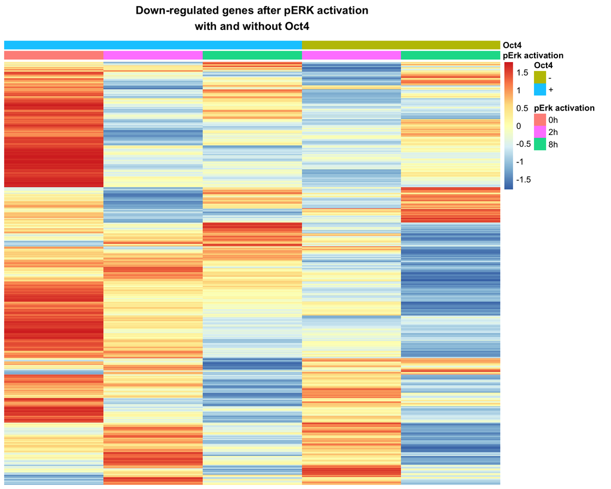

```r
pheatmap(heatmap_data, show_rownames = F, cluster_cols = F, treeheight_row = 0, scale = "row",
         show_colnames = F, annotation_col = annot_col,
         main = "Down-regulated genes after pERK activation\nwith and without Oct4")
```

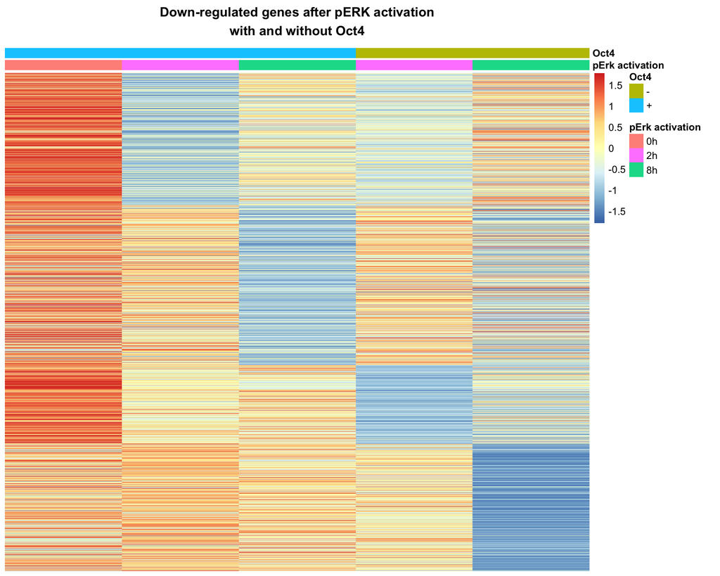

```r
pheatmap(heatmap_data, show_rownames = F, cluster_cols = F, treeheight_row = 0, scale = "row",
         show_colnames = F, annotation_col = annot_col, cluster_rows = F,
         main = "Down-regulated genes after pERK activation\nwith and without Oct4")
```

Divide clusters and do only 2 and 8h

```r
cluster_2h <- t(scale(t(heatmap_data[,c("H2O_NA_8h","H2O_4OHT_2h", "DOX_4OHT_2h")])))
cluster_2h <- hclust(dist(cluster_2h))

cluster_8h <- t(scale(t(heatmap_data[,c("H2O_NA_8h","H2O_4OHT_8h", "DOX_4OHT_8h")])))
cluster_8h <- hclust(dist(cluster_8h))
```

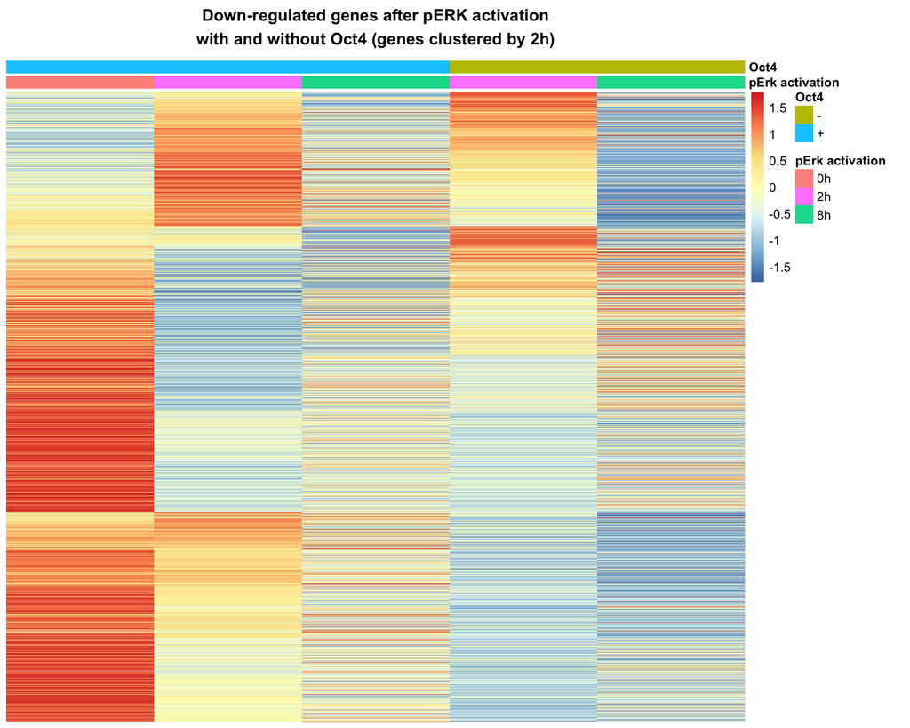

```r
pheatmap(heatmap_data, show_rownames = F, cluster_cols = F, cluster_rows = cluster_2h,
         treeheight_row = 0, scale = "row", show_colnames = F, annotation_col = annot_col,
         main = "Down-regulated genes after pERK activation\nwith and without Oct4 (genes clustered by 2h)")
```

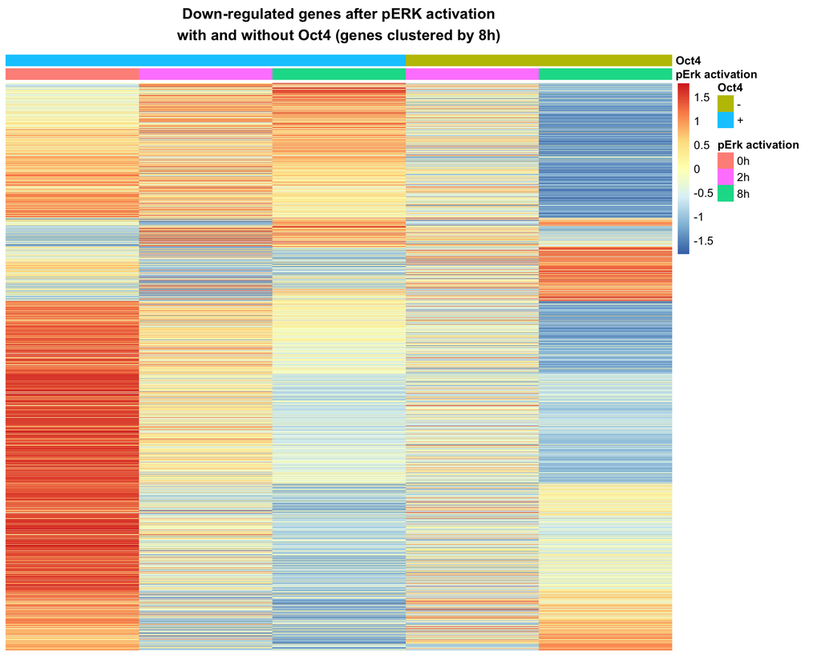

```r
pheatmap(heatmap_data, show_rownames = F, cluster_cols = F,cluster_rows = cluster_8h,
         treeheight_row = 0, scale = "row", show_colnames = F, annotation_col = annot_col,
         main = "Down-regulated genes after pERK activation\nwith and without Oct4 (genes clustered by 8h)")
```